# RepData_PeerAssessment2

by Fabio Bianchini

30/04/2017

## Synopsis

In this analysis it will use the **U.S. National Oceanic and Atmospheric Administration’s (NOAA) storm database** to answer this to question:

1. Across the United States, which types of events (as indicated in the 𝙴𝚅𝚃𝚈𝙿𝙴 variable) are most harmful with respect to population health?
2. Across the United States, which types of events have the greatest economic consequences?

## Data processing

##### Loading Raw Data

```r
url <- "https://d396qusza40orc.cloudfront.net/repdata%2Fdata%2FStormData.csv.bz2"
download(url, "Storm_Data.bz2", mode = "wb") #Download dataset from specific URL
bunzip2("Storm_Data.bz2", "Storm_data.csv", remove = FALSE, skip = TRUE) # unzip data file
```

```
## [1] "Storm_data.csv"
## attr(,"temporary")
## [1] FALSE
```

```r
Storm_Data <- read.csv("Storm_data.csv") #
```

```r
dim(Storm_Data) # Original dataset dimension
```

```
## [1] 902297     37
```

```r
names(Storm_Data) # Variables name in the orginal dataset
```

```
##  [1] "STATE__"    "BGN_DATE"   "BGN_TIME"   "TIME_ZONE"  "COUNTY"
##  [6] "COUNTYNAME" "STATE"      "EVTYPE"     "BGN_RANGE"  "BGN_AZI"
## [11] "BGN_LOCATI" "END_DATE"   "END_TIME"   "COUNTY_END" "COUNTYENDN"
## [16] "END_RANGE"  "END_AZI"    "END_LOCATI" "LENGTH"     "WIDTH"
## [21] "F"          "MAG"        "FATALITIES" "INJURIES"   "PROPDMG"
## [26] "PROPDMGEXP" "CROPDMG"    "CROPDMGEXP" "WFO"        "STATEOFFIC"
## [31] "ZONENAMES"  "LATITUDE"   "LONGITUDE"  "LATITUDE_E" "LONGITUDE_"
## [36] "REMARKS"    "REFNUM"
```

##### Process/transform the data into a format suitable for the analysis

```r
ds1 <- as_tibble(Storm_Data)
# variable must have a unique name in the dataset
names(ds1)[names(ds1)=="STATE__"] <- "STATE_NUM"
names(ds1)[names(ds1)=="LONGITUDE_"] <- "LONGITUDE_E"
names(ds1) <- str_to_lower(names(ds1)) # Force lowercase dataset columb names
names(ds1) <-str_replace(names(ds1), "_+$","") # Remove final underscore from columb names
names(ds1) <- str_replace(names(ds1), "_",".") #
names(ds1)
```

```
##  [1] "state.num"   "bgn.date"    "bgn.time"    "time.zone"   "county"
##  [6] "countyname"  "state"       "evtype"      "bgn.range"   "bgn.azi"
## [11] "bgn.locati"  "end.date"    "end.time"    "county.end"  "countyendn"
## [16] "end.range"   "end.azi"     "end.locati"  "length"      "width"
## [21] "f"           "mag"         "fatalities"  "injuries"    "propdmg"
## [26] "propdmgexp"  "cropdmg"     "cropdmgexp"  "wfo"         "stateoffic"
## [31] "zonenames"   "latitude"    "longitude"   "latitude.e"  "longitude.e"
## [36] "remarks"     "refnum"
```

```r
# Remove the observation with no interest for answer the question for this analysis
ds2 <- ds1[ds1$fatalities > 0 | ds1$injuries > 0 | ds1$cropdmg > 0 | ds1$propdmg > 0,]
dim(ds2)
```

```
## [1] 254633     37
```

## Result

##### 1. Across the United States, which types of events (as indicated in the 𝙴𝚅𝚃𝚈𝙿𝙴 variable) are most harmful with respect to population health?

The variables of interest, for analazing the impact on population healt are `fatalites` and `injuries`so we create a subset from the original dataset with only the variable of interest.

```r
# Create a dataset with only the columb/variable of interest to answer this question
ds3 <- select(ds2, fatalities, injuries, evtype)
# Force all `evtypes` to uppercase
ds3$evtype <- str_to_upper(ds3$evtype)
# replace multiple spaces with single space
ds3$evtype <- gsub(" +", " ", ds3$evtype)
# Summarize fatalities and injuries valure grouped by `evtype`
ds4 <- ds3 %>% group_by(evtype) %>%
        summarise(tot.fatalities = sum(fatalities), tot.injuries = sum(injuries))

# Dimension for summarized dataset
dim(ds4) #
```

```
## [1] 443   3
```

```r
# Re-organize the dataset
fatalities <- arrange(ds4, desc(tot.fatalities))
head(fatalities)
```

```
## # A tibble: 6 × 3
##           evtype tot.fatalities tot.injuries
##            <chr>          <dbl>        <dbl>
## 1        TORNADO           5633        91346
## 2 EXCESSIVE HEAT           1903         6525
## 3    FLASH FLOOD            978         1777
## 4           HEAT            937         2100
## 5      LIGHTNING            816         5230
## 6      TSTM WIND            504         6957
```

**Fatalitis analysis**

For this analysis we will consider only the events with n. of fatalities greater that the mean

```r
plot_fatalities <- fatalities[fatalities$tot.fatalities > mean(fatalities$tot.fatalities), ]
nrow(plot_fatalities) # Events with n. of fatalities greater that the mean
```

```
## [1] 34
```

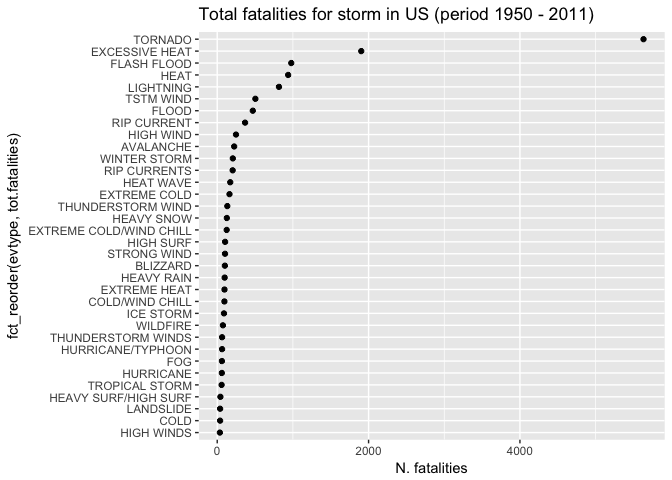

```r
ggplot(plot_fatalities, aes(tot.fatalities, fct_reorder(evtype, tot.fatalities))) + geom_point() + labs(title="Total fatalities for storm in US (period 1950 - 2011)", x = "N. fatalities")
```

The TORNADO event has most harmful impact on public health with n. **5633** total fatalities.

*The first 10th Fatalities events*

```r
library(knitr)
kable(plot_fatalities[1:10,], col.names = c("Type of Events","Total Fatalities", "Total injuries") )
```

| Type of Events | Total Fatalities | Total injuries |
| --- | --- | --- |
| TORNADO | 5633 | 91346 |
| EXCESSIVE HEAT | 1903 | 6525 |
| FLASH FLOOD | 978 | 1777 |
| HEAT | 937 | 2100 |
| LIGHTNING | 816 | 5230 |
| TSTM WIND | 504 | 6957 |
| FLOOD | 470 | 6789 |
| RIP CURRENT | 368 | 232 |
| HIGH WIND | 248 | 1137 |
| AVALANCHE | 224 | 170 |

**Injuries analysis**

For this analysis we will consider only the events with n. of injuries greater that the mean

```r
injuries <- arrange(ds4, desc(tot.injuries))
mean(injuries$tot.injuries) # Mean value for injuries
```

```
## [1] 317.219
```

```r
plot_injuries <- injuries[injuries$tot.injuries > mean(injuries$tot.injuries), ]
nrow(plot_injuries) # Events with n. of injuries greater that the mean
```

```
## [1] 24
```

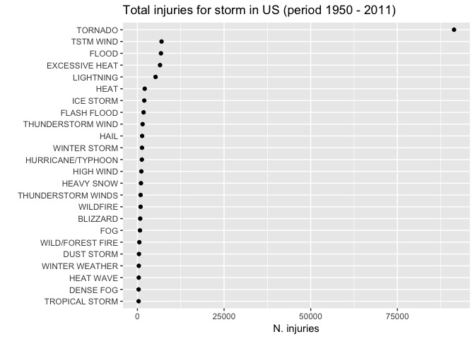

```r
ggplot(plot_injuries, aes(tot.injuries, fct_reorder(evtype, tot.injuries))) + geom_point() + labs(title="Total injuries for storm in US (period 1950 - 2011)", x="N. injuries", y="")
```

The TORNADO event has most harmful impact on public health with n. **91346** total injuries.

*The first 10th injuries events*

```r
library(knitr)
kable(plot_injuries[1:10,], col.names = c("Type of Events","Total Fatalities", "Total injuries"))
```

| Type of Events | Total Fatalities | Total injuries |
| --- | --- | --- |
| TORNADO | 5633 | 91346 |
| TSTM WIND | 504 | 6957 |
| FLOOD | 470 | 6789 |
| EXCESSIVE HEAT | 1903 | 6525 |
| LIGHTNING | 816 | 5230 |
| HEAT | 937 | 2100 |
| ICE STORM | 89 | 1975 |
| FLASH FLOOD | 978 | 1777 |
| THUNDERSTORM WIND | 133 | 1488 |
| HAIL | 15 | 1361 |

##### 2. Across the United States, which types of events have the greatest economic consequences?

The variables of interest for analazing the **greatest economic consequences of a Storm event** are `Property damage` and `Crop damage`, so we create a subset from the original dataset with only the variables of interest

```r
damage <- select(ds2, evtype, propdmg, propdmgexp, cropdmg, cropdmgexp)
```

Due to the particulary form for storm data damage in the original dataset, we need to convert this variables in a form suitable per the correct analysis and rappresentation.

```r
# Convert cropdmgexp and propdmgexp variables
damage$propdmgexp <- as.character(damage$propdmgexp)
damage$cropdmgexp <- as.character(damage$cropdmgexp)
damage$propdmgexp <- str_to_upper(damage$propdmgexp)
damage$cropdmgexp <- str_to_upper(damage$cropdmgexp)
#
damage$propdmg.value <- 0 # New dataset columb for property damage value
damage[damage$propdmgexp == "K", ]$propdmg.value <- 3
damage[damage$propdmgexp == "M", ]$propdmg.value <- 6
damage[damage$propdmgexp == "B", ]$propdmg.value <- 7
#
damage$cropdmg.value <- 0 # New dataset columb for crop damage value
damage[damage$cropdmgexp == "K", ]$cropdmg.value <- 3
damage[damage$cropdmgexp == "M", ]$cropdmg.value <- 6
damage[damage$cropdmgexp == "B", ]$cropdmg.value <- 7
#
damage$totdmg.value <- 0 # New dataset columb for total damage value
names(damage)
```

```
## [1] "evtype"        "propdmg"       "propdmgexp"    "cropdmg"
## [5] "cropdmgexp"    "propdmg.value" "cropdmg.value" "totdmg.value"
```

Now valorize the new `total damage value` columb as a `total property damage` and `total crop damage` value summ

```r
damage$totdmg.value <- damage$propdmg*(10^damage$propdmg.value) + damage$cropdmg*(10^damage$cropdmg.value)
```

```r
# Summarize property damage and crop damage valure grouped by `evtype`
ds5 <- damage %>% group_by(evtype) %>% summarise(total = sum(totdmg.value))
plot_damage <- arrange(ds5, desc(total))
# For the plot porpuose we consider only events with total damage value greater that the mean
plot_damage <- plot_damage[plot_damage$total > mean(plot_damage$total), ]
nrow(plot_damage) # Events with total damage amount greater that the mean
```

```
## [1] 29
```

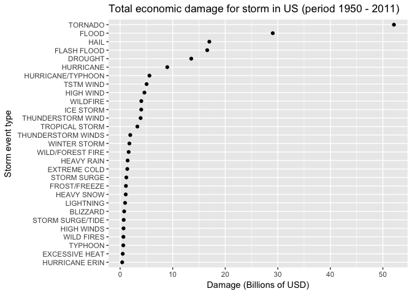

```r
ggplot(plot_damage, aes(total/10^9, fct_reorder(evtype, total))) + geom_point() + labs(title="Total economic damage for storm in US (period 1950 - 2011)", x="Damage (Billions of USD)", y="Storm event type")
```

*The first 10th great economic events*

```r
library(knitr)
plot_damage$total <- as.integer(plot_damage$total/10^9)
kable(plot_damage[1:10,], col.names = c("Type of Events", "Economic damage (Billions of USD)"))
```

| Type of Events | Economic damage (Billions of USD) |
| --- | --- |
| TORNADO | 52 |
| FLOOD | 29 |
| HAIL | 16 |
| FLASH FLOOD | 16 |
| DROUGHT | 13 |
| HURRICANE | 8 |
| HURRICANE/TYPHOON | 5 |
| TSTM WIND | 5 |
| HIGH WIND | 4 |
| WILDFIRE | 4 |